# SAVOR: Part II

June 6<sup>th</sup>, 2024

## **Literate programming**

80’s idea from D. Knuth:

> write code for humans, not for computer

## Dynamic reporting

One document to rule them all with **both text** & **code**  
=> export to different formats

## Reproducible research

**Science reproducibility crisis**

- Is most scientific research false ? *Ioanidis et al.*
- have you had to redo a whole analysis with just slightly different data  
  (e.g. 1 patient added or removed ?)

Fench book on reproducible research:

[*Vers une recherche reproductible : faire évoluer ses pratiques*](https://rr-france.github.io/bookrr/)

## In : `.qmd` (“Quarto markdown”)

[figure not shown]

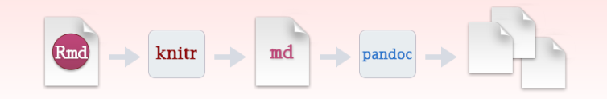

(*These materials have been prepared in Rmarkdown & Quarto*)

## `.qmd` structure

1. YAML Header

```yaml
---
title: 'SAVOR: Part II'
subtitle: "Dynamic & Reproducible reporting with `Quarto`"
author: "Boris Hejblum"
date: "06/06/2024"
output:
  ioslides_presentation:
    number_sections: false
---
```

- Text  
  **Narration**
- Code Chunks

```{r}  
```

## Code chunks

## Basic chunk options

- `results` (default is `'markup'`)
  - `'asis'` - passthrough results
  - `'hide'` - do not display results
  - `'hold'` - put all results below all code
- `eval` - Run code in chunk (default is `TRUE`)
- `echo` - Display code in output document (default is `TRUE`)
- `message` - display code messages in document (default is `TRUE`)
- `error` - Display error messages in output document (`TRUE`) or stop render when errors occur (`FALSE`)  
  (default is `FALSE`)

## Code display options

- `tidy` - tidy code for display (default is FALSE)
- `warning` - display code warnings in document (default = TRUE)
- `collapse` - collapse all output into single block (default = FALSE)
- `highlight` - highlight source code (default = TRUE)
- `include` - include chunk in doc after running (default = TRUE)
- `comment` - prefix for each line of results (default = ‘##’)

## Plots & figures

- `fig.align` - figure postion: `'left'`, `'right'`, or `'center'`
- `fig.cap` - figure caption as character string (default is `NULL`)
- `fig.height`, `fig.width` - Dimensions of plots in inches
- `out.width` - only in pdf: size of the figure

## *cache*

Long running code chunks

- `cache` - cache results for future knits (default is `FALSE`)
- `cache.path` - directory to save cached results in (default is `"cache/"`)
- `dependson` - chunk dependencies for caching (default is `NULL`)

## Additional features

### Multiple files

- `child` - file(s) to knit and then include (default is `NULL`)

## Text

## Markdown syntax

- `*italic*` — *italic*
- `**bold**` — **bold**
- `~~no~~` — strikethrough
- `code` — `verbatim code`
- `^2^` — superscript<sup>2</sup>
- `~2~` — subscript<sub>2</sub>
- `$\alpha = \beta^2$` — LaTeX equations: \(\alpha = \beta^2\)
- End a line with two spaces to start a new paragraph

## Headings & cross-references

### Headings

# Header1 {#anchor}  
## Header 2

Jump to `[Header 1](#anchor)`

### Footnotes

A footnote `[^1]`  
`[^1]`: Here is the footnote.

### Include images

`![Caption](pathtoimage.png)`

## Lists and Bullets in markdown

```r
 - Bullet 1
 - Bullet 2
```

- Bullet 1
- Bullet 2

```r
1. item 1
2. item 2
```

1. item 1
2. item 2

## Tables

`| Right | Left | Default | Center |`  
`|------:|:-----|---------|:------:|`  
`| 12 | 12 | 12 | 12|`  
`| 123 | 123 | 123 | 123 |`  
`| 1 | 1 | 1 | 1 |`

| Right | Left | Default | Center |
| --- | --- | --- | --- |
| 12 | 12 | 12 | 12 |
| 123 | 123 | 123 | 123 |
| 1 | 1 | 1 | 1 |

## Bibliography

```yaml
---
bibliography: refs.bib
csl: style.csl
---
```

Smith cited `[@smith04]`.  
Smith cited without author `[-@smith04]`.  
`@smith04` cited in line.

## Additional resources

- [Rstudio `Rmarkdown` cheatsheet](https://rstudio.github.io/cheatsheets/rmarkdown.pdf)
- [Rstudio `Quarto` cheatsheet](https://rstudio.github.io/cheatsheets/quarto.pdf)
- [*Rmarkdown* book by Yihui Xie, JJ Allaire & G Grolemund](https://bookdown.org/yihui/rmarkdown/)  
  (very) comprehensive…

## `.qmd` practical

1. create a new .qmd file
2. play along with the various options described here
3. try various output formats
4. turn your answers to the first practical into a `.qmd`